# 1) Preprocessing and QC filtering

2025-10-23

This script performs preprocessing and quality control (QC) filtering of single-cell RNA sequencing (scRNA-seq) data generated using conventional 10x Genomics, FLEX, and Parse Biosciences Mini and Midi kits. The R package CRMetrics is utilized for QC in this script. While the published version of CRMetrics (https://github.com/khodosevichlab/CRMetrics) is only compatible with conventional 10x Genomics data, a local adaptation has been implemented to support 10x FLEX and Parse Biosciences data. Additionally, this version incorporates compatibility with the latest CellBender release (version 0.3.0). For large datasets (~ 100,000 nuclei) memory limitations of R (e.g. with Conos and CRMetrics) necessitate transitioning to Python for data analysis. More information and application of the CRMetrics package can be found here: http://kkh.bric.ku.dk/rasmus/CRMetrics/walkthrough.html

QC filtering involves iterative adjustments to determine the optimal thresholds for filtering depth (unique molecular identifiers [UMIs] per cell), mitochondrial (mito) fraction (percentage of mitochondrial gene expression per cell), and doublets (two or more cells clustered together). Final clustering is not conducted in this script, it is addressed in a subsequent script, “Clustering_and_annotation”.

If ambient RNA filtering is applied, it is performed first, followed by filtering based on depth, mitochondrial fraction, and doublets. At the end of the pipeline, a new CRMetrics object is constructed using the filtered count matrices (=cms) to plot the violin plots for UMI and gene counts post-filtering.

Due to its computational intensity, ambient RNA filtering is not part of the standard analysis pipeline but is performed upon specific user request.

# 1. Inspection of reports produced by count pipelines

First step in QC is to inspect the summary reports produced by the cell calling pipelines (e.g. cellranger count for 10x platform). Check if any warnings or errors are present and check shape of barcode-rank-plot (cliff and knee). Those summary reports are shared with the user.

# 2. fastQC and multiQC

Inspect sequencing quality by running fastQC and multiQC on fastq data. MultiQC can also be run on cellranger count outputs to get a sample metrics overview. Links to multiQC reports can be provided. MultiQC does not yet work on cellranger multi (FLEX) and Parse output.

# 3. Create CRMetrics object

# Setup

```r
# loading locally adapted CRMetrics version for Parse, 10xFlex, new version of cellbender
load_all("/people/nrq364/CRMetrics_LW")
```

[output not shown]

In case of Parse data use data.path to “combined” folder, for 10x FLEX data.path to “per_sample_outs” folder. Metadata should at least contain “sample” and “group/condition” but can have more columns.

```r
crm <- CRMetrics$new(data.path = "/data/counts/[project_name]/",
                     metadata = "path_to_metadata.csv",
                     n.cores = 60)
```

```r
crm$metadata
```

| sample | condition | version |
| --- | --- | --- |
| control_1 | control | v3 |
| control_2 | control | v3 |
| control_4 | control | v3 |
| control_5 | control | v3.1 |
| control_6 | control | v3.1 |
| control_7 | control | v3.1 |
| treated_1 | treated | v3 |
| treated_2 | treated | v3 |
| treated_3 | treated | v3 |
| treated_4 | treated | v3 |

[output cut: 2 more lines]

```r
qsave(crm, "crm.qs", nthreads = 10)
```

# 4. Basic metrics

Show available metrics to plot.

```r
crm$selectMetrics()
```

| no | metrics |
| --- | --- |
| 1 | estimated number of cells |
| 2 | mean reads per cell |
| 3 | median genes per cell |
| 4 | number of reads |
| 5 | valid barcodes |
| 6 | sequencing saturation |
| 7 | q30 bases in barcode |
| 8 | q30 bases in rna read |
| 9 | q30 bases in umi |
| 10 | reads mapped to genome |

[output cut: 9 more lines]

## 4.1 Plot selected metrics per sample

From list of metrics above, you can choose which barplots you would like to receive if the default ones are not sufficient. Default metrics: estimated number of cells, mean reads per cell, median genes per cell, total genes detected, median UMI counts per cell

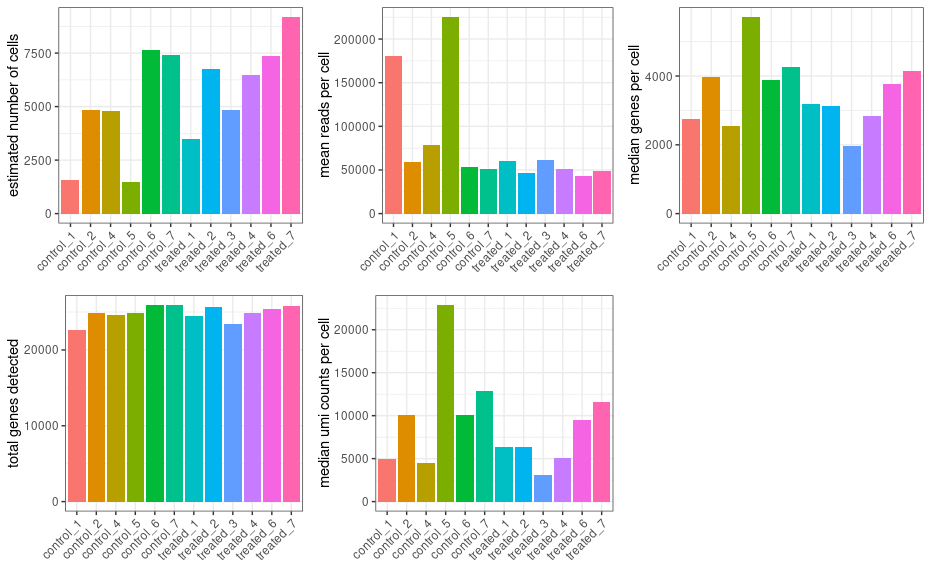

```r
metrics.to.plot <- crm$selectMetrics(ids = c(1:3,18,19))
crm$plotSummaryMetrics(plot.geom ="bar", comp.group = "sample", metrics = metrics.to.plot)
```

## 4.2 Plot selected metrics per condition

[figure not shown]

```r
crm$plotSummaryMetrics(comp.group = "condition",
                       metrics = metrics.to.plot,
                       plot.geom = "point",
                       stat.test = "non-parametric") #second.comp.group= "sex"
```

## 4.3 Add and plot detailed metrices

```r
crm$addCms(add.metadata=F) #for Parse data: parse = T, for FLEX: flex = T
crm$addDetailedMetrics(n.cores = 30)
```

get total number of sequenced nuclei

```r
sum(sapply(crm$cms, function(d) dim(d)[2]))
```

[output not shown]

plot UMIs and genes per sample before filtering, horizontal lines indicate the median values for all samples

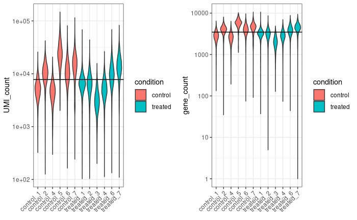

```r
crm$plotDetailedMetrics(comp.group = "condition",
                        metrics = c("UMI_count",  "gene_count"),
                        plot.geom = "violin")
```

Generate a data frame with the metrics.

```r
metrics <- crm$summary.metrics
metrics %<>% as.data.frame()
metrics
```

| sample | metric | value |
| --- | --- | --- |
| control_1 | estimated number of cells | 1.574000e+03 |
| control_1 | mean reads per cell | 1.806140e+05 |
| control_1 | median genes per cell | 2.752000e+03 |
| control_1 | number of reads | 2.842866e+08 |
| control_1 | valid barcodes | 9.540000e-01 |
| control_1 | sequencing saturation | 9.030000e-01 |
| control_1 | q30 bases in barcode | 9.640000e-01 |
| control_1 | q30 bases in rna read | 9.370000e-01 |
| control_1 | q30 bases in umi | 9.620000e-01 |
| control_1 | reads mapped to genome | 9.020000e-01 |

[output cut: 218 more lines]

Get median genes per cell across all samples before filtering (in case of Parse: “hg38_median_genes_per_cell”).

```r
median(metrics[metrics$metric=="median genes per cell",]$value)
```

```
[1] 3478
```

Get median UMIs per cell across all samples before filtering (in case of Parse: “hg38_median_tscp_per_cell”).

```r
median(metrics[metrics$metric=="median umi counts per cell",]$value)
```

```
[1] 7945
```

# 5. Embed cells using conos

To plot the cells in an embedding, we need to preprocess the raw count matrices with pagoda2 (seurat is also possible).

```r
crm$doPreprocessing() #min.transcripts.per.cell = 100
```

Create embedding using conos. This functions executes the functions Conos$new(cms, n.cores = n.cores), buildGraph(), findCommunities(), embedGraph(method = “UMAP”), with default settings, which can be adjusted.

```r
crm$createEmbedding()
```

Plot the embedding. This is before filtering, so we are not yet interested in the clusters, those are refined in the next script.

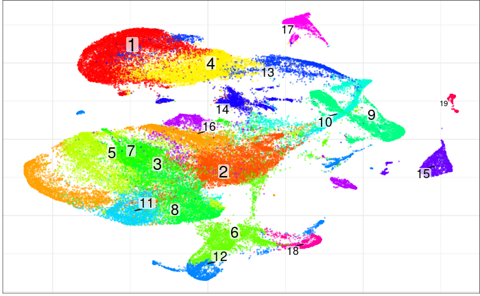

```r
crm$plotEmbedding()
```

# 6. Filtering out low quality cells

## 6.1 Cell depth (= UMI counts per cell) as histogra

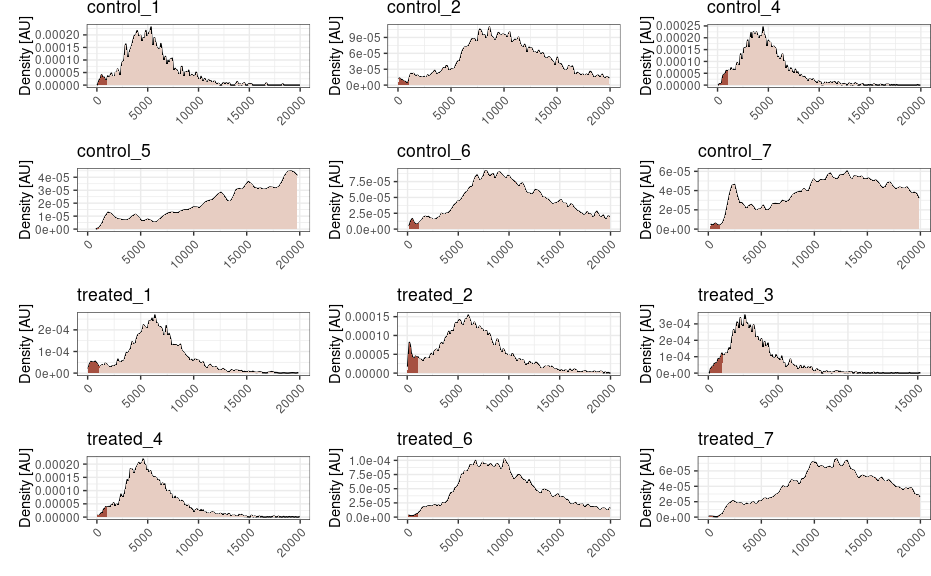

```r
crm$plotDepth()
```

If the depth distribution varies between samples, we can use sample-specific cutoffs.

```r
depth_cutoff_vec <- c(1e3, 1e3, 500, 1e3, 1e3, 500, 1e3, 1e3, 1e3, 1e3, 1e3, 500) %>%
  setNames(crm$detailed.metrics$sample %>%
             unique() %>%
             sort())

depth_cutoff_vec
```

```
control_1 control_2 control_4 control_5 control_6 control_7 treated_1 treated_2 treated_3 treated_4 treated_6 treated_7
     1000      1000       500      1000      1000       500      1000      1000      1000      1000      1000       500
```

Plot sample specific cutoff in histogram and embedding.

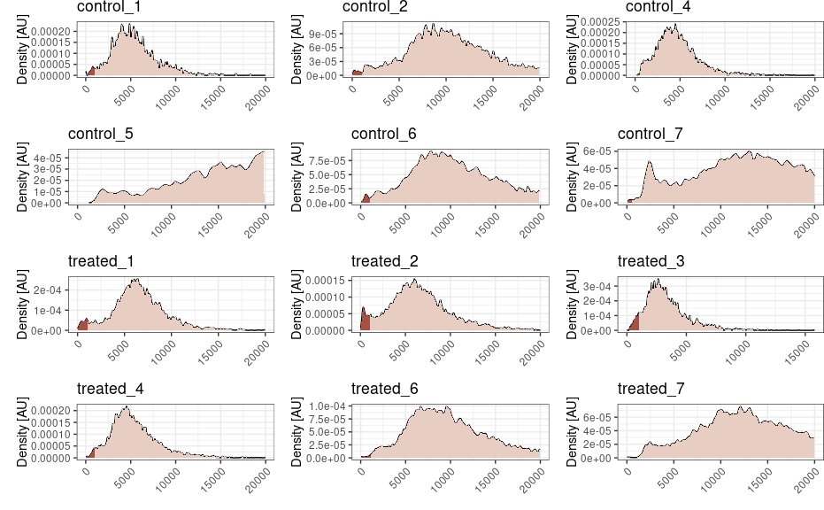

```r
crm$plotDepth(cutoff = depth_cutoff_vec)
```

## 6.2 Cell depth on UMAP

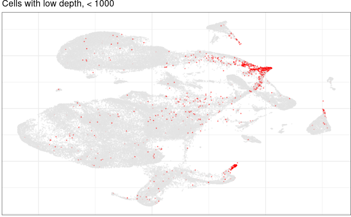

```r
crm$plotEmbedding(depth = TRUE,
             depth.cutoff = 1000)
```

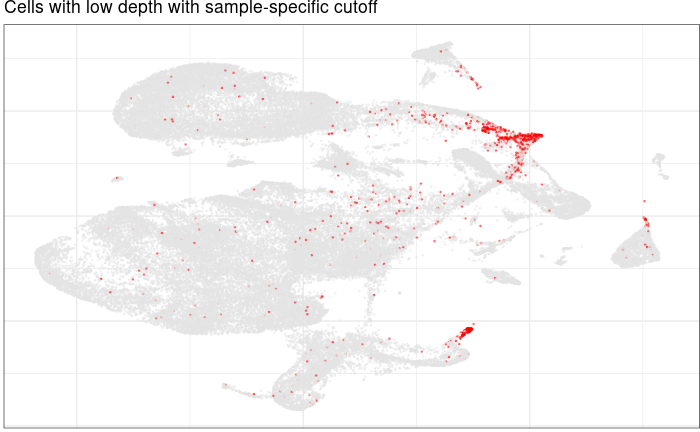

```r
crm$plotEmbedding(depth = TRUE,
             depth.cutoff = depth_cutoff_vec)
```

## 6.3 Plot cell depth distribution on UMAP

colour cells in embedding based on UMI count (dark purple: low UMI count; white: high UMI count)

```r
cms <- crm$con$getJointCountMatrix()
umi_counts <- Matrix::rowSums(cms)
```

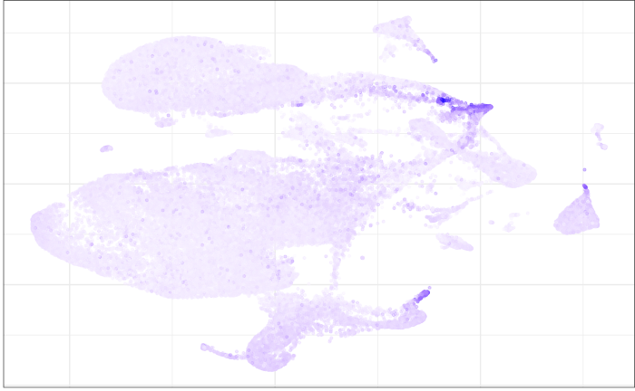

```r
crm$con$plotGraph(colors = umi_counts ) + scale_color_gradient(low = "blue", high = "white")
```

## 6.4 Mitochondrial gene fraction

Investigate the mitochondrial gene fraction in the cells. A high mito fraction indicates dying or raptured cells. The example dataset has a very low expression of mitochondrial genes. Usual cutoff is 5% (in mouse tissue) or higher (in postmortem human samples).

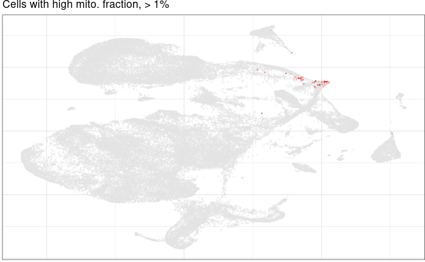

```r
crm$plotEmbedding(mito.frac = TRUE,
             mito.cutoff = 0.01,
             species = "mouse")
```

We can plot the distribution of the mitochondrial fraction per sample and also include sample-wise cutoffs (not shown here as the example dataset has only a very low expression of mitochondrial genes).

## 6.5 Doublet detection

Doublet detection within CRMetrics is possible with the python packages scrublet or DoubletDetection. Scrublet is the default method, which is fast. DoubletDetection is significantly slower, but performs better according to this review (https://www.sciencedirect.com/science/article/pii/S2405471220304592). Which one to choose depends on the dataset and technology used.

Here we use scrublet as default method. A virtual environment is used to install scrublet.

```r
library(reticulate)
conda_create("scrublet",
             conda = "/opt/software/miniconda/4.12.0/condabin/conda",
             python_version = 3.8)
```

Scrublet is run from within R or a Python script is generated to run it from the terminal. To do this, set export = TRUE and run python scrublet.py inside the virtual environment to generate data.

```r
crm$detectDoublets(env = "scrublet",
                   conda.path = "/opt/software/miniconda/4.12.0/condabin/conda",
                   method = "scrublet")
```

Then, load data with:

```r
crm$addDoublets()
```

Plot the estimated doublets in the embedding.

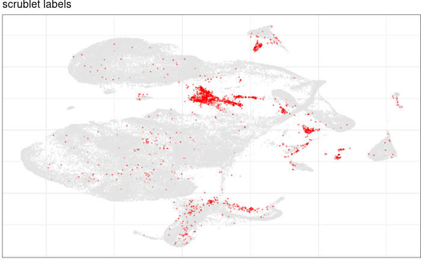

```r
crm$plotEmbedding(doublet.method = "scrublet")
```

## 6.6 Plot filtered cells

Plot all cells to be filtered on the embedding.

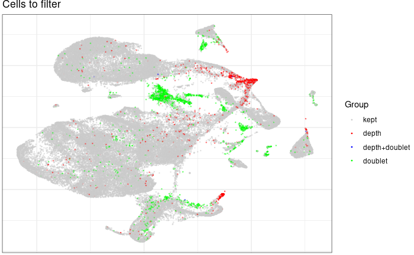

```r
crm$plotFilteredCells(type = "embedding",
                      depth = TRUE,
                      depth.cutoff = 1000,
                      doublet.method = "scrublet",
                      mito.frac = FALSE,
                      species = "mouse")
```

Plot the cells to be filtered per sample in a bar plot where combination means a cell that has at least two filter labels, e.g. doublet and depth.

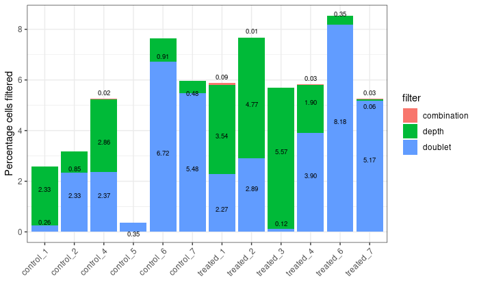

```r
crm$plotFilteredCells(type = "bar",
                      depth = TRUE,
                      depth.cutoff = 1000,
                      doublet.method = "scrublet",
                      mito.frac = FALSE,
                      species = "mouse")
```

# 7. Filter and save count matrices

Finally, filter the count matrices to be used in downstream applications. If cellbender should be used then cms needs to be added after cellbender and then all subsequent filtering is done.

```r
crm$filterCms(depth.cutoff = 1000,
              mito.cutoff = NULL,
              doublets = "scrublet",
              samples.to.exclude = NULL,
              species = "mouse",
              verbose = TRUE)
```

```
2025-10-10 14:12:35.799257 Preparing filter
2025-10-10 14:12:39.205168 Removing 3745 of 61949 cells (6.05%)
```

```r
qsave(crm, "crm.qs")
```

The filtered list of count matrices is stored in $cms.filtered which can be saved on disk.

```r
qsave(crm$cms.filtered, "cms_filtered[_cellbender].qs",
      nthreads = 10)
```

# 8. Plot detailed metrics after filtering

```r
cms <- qread("cms_filtered[_cellbender].qs")
```

Create a new crm object with cms after filtering.

```r
crm_filtered <- CRMetrics$new(cms = crm$cms.filtered, n.cores = 60, metadata="/projects/thor/people/nrq364/metadata_without_ctrl3_and_treated5.csv")
```

```
Adding list of 12 count matrices.
```

```r
crm_filtered$addSummaryFromCms()
```

```
2025-10-10 14:19:48.834193 Calculating 12 summaries using 12 cores
2025-10-10 14:20:05.260725 Done!
```

```r
crm_filtered$addDetailedMetrics(n.cores = 30)
```

```
2025-10-10 14:20:06.705643 Counting using 12 cores
2025-10-10 14:20:21.928334 Creating table
2025-10-10 14:20:21.983581 Done!
```

Total number of nuclei retained after QC:

```r
sum(sapply(crm_filtered$cms, function(d) dim(d)[2]))
```

```
[1] 58204
```

```r
qsave(crm_filtered, "crm_filtered.qs")
```

## 8.1 Violin plots of UMIs and genes

Plot UMIs and genes per sample after QC filtering, horizontal lines indicate the median values for all samples.

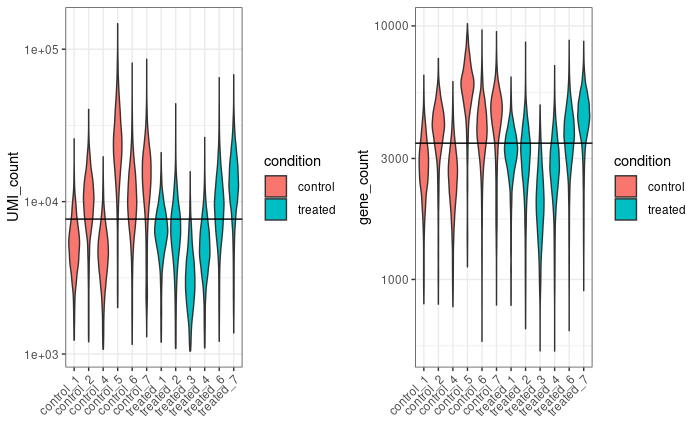

```r
crm_filtered$plotDetailedMetrics(comp.group = "condition",
                        metrics = c("UMI_count",  "gene_count"),
                        plot.geom = "violin")
```

Generate a data frame with the metrics.

```r
metrics <- crm_filtered$summary.metrics
metrics %<>% as.data.frame()
metrics
```

| sample | metric | value |
| --- | --- | --- |
| control_1 | estimated number of cells | 1502.0 |
| control_1 | median genes per cell | 2796.0 |
| control_1 | median umi counts per cell | 5123.5 |
| control_1 | total genes detected | 22433.0 |
| control_2 | estimated number of cells | 4565.0 |
| control_2 | median genes per cell | 3990.0 |
| control_2 | median umi counts per cell | 10110.0 |
| control_2 | total genes detected | 24727.0 |
| control_4 | estimated number of cells | 4512.0 |
| control_4 | median genes per cell | 2520.0 |

[output cut: 38 more lines]

Median genes per cell across all samples after QC filtering (in case of Parse: “hg38_median_genes_per_cell”).

```r
median(metrics[metrics$metric=="median genes per cell",]$value)
```

```
[1] 3454
```

Median UMIs per cell across all samples after QC filtering (in cas of Parse: “hg38_median_tscp_per_cell”).

```r
median(metrics[metrics$metric=="median umi counts per cell",]$value)
```

```
[1] 7814
```

# 9. Optional: remove ambient RNA

We use usually use cellbender, SoupX is also included in CRMetrics. Perform this step before filtering, it changes the number of called cells and their gene counts.

In the old cellbender version (before 0.3.0) we needed to specify expected number of cells and total droplets included. As hinted in the manual, the number of total droplets included could be expected number of cells multiplied by 3, this can still be plotted here when setting show.total.droplets=T. Additionally, in case of Parse, the following function creates the input files for cellbender from the Parse output.

```
2025-10-10 14:29:58.322349 Started run using 12 cores
2025-10-10 14:29:58.328837 Loading HDF5 Cell Ranger outputs
2025-10-10 14:29:58.668294 Loading 12 count matrices using 12 cores
2025-10-10 14:30:38.799796 Done!
2025-10-10 14:30:38.802198 Calculating UMI counts per sample
2025-10-10 14:30:59.9581 Plotting
2025-10-10 14:31:00.238967 Done!
```

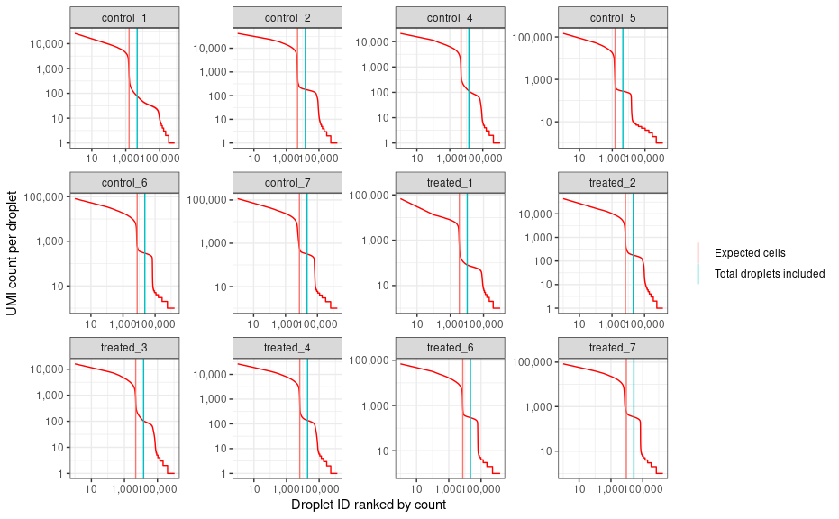

```r
crm$prepareCellbender(show.expected.cells = T, show.total.droplets = T)
```

CHECK WITH NEW CRMETRICS VERSION!!

The following function prepares and saves the cellbender script. To only select specific samples, use the samples parameter. total.droplets and expected.cells is a logical because in cellbender from v0.3.0 total.droplets and expected.cells do not need to be specified anymore.  
○ FALSE is default  
○ TRUE would take expected.cells from metadata and total droplets would be 3x expected cells  
○ alternatively give own numbers (named vector)

```r
crm$saveCellbenderScript(file = "cellbender_script.sh",
                         fpr = 0.01,
                         epochs = 150,
                         use.gpu = TRUE, total.droplets = F, expected.cells = F) # could be total.droplets = droplets (named vector)
```

We can run this script in the terminal (screen session). Here, we activate the environment: conda activate cellbender_v0.3.0 and we run the bash script: sh cellbender_script.sh.

## 9.1 Plot cellbender cell numbers

Plot the changes in cell numbers following CellBender estimations.

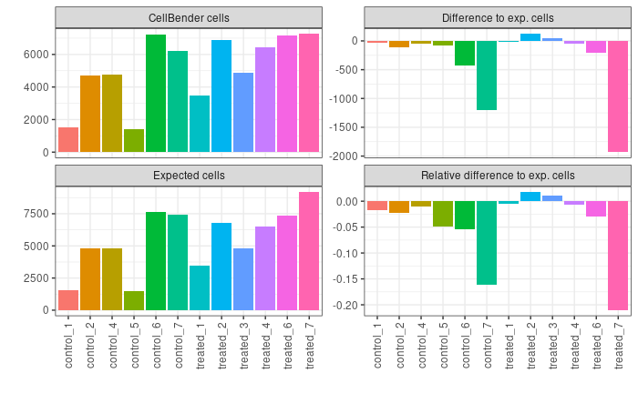

```r
crm$plotCbCells()
```

## 9.2 Plot the CellBender training results.

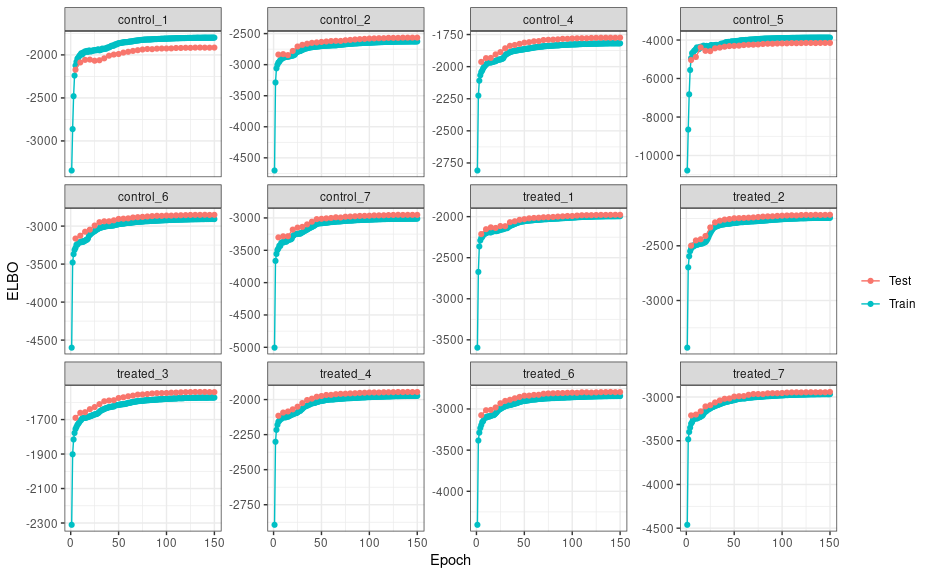

```r
crm$plotCbTraining()
```

## 9.3 Plot the cell probabilities.

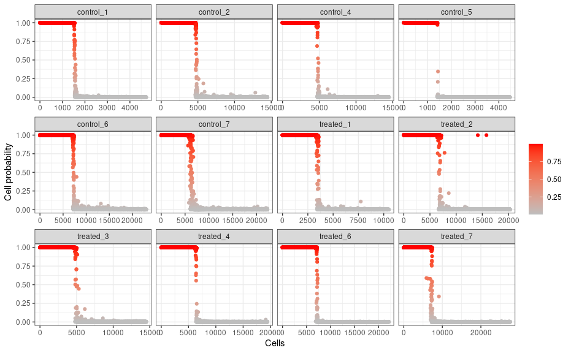

```r
crm$plotCbCellProbs()
```

## 9.4 Plot the identified ambient genes per sample.

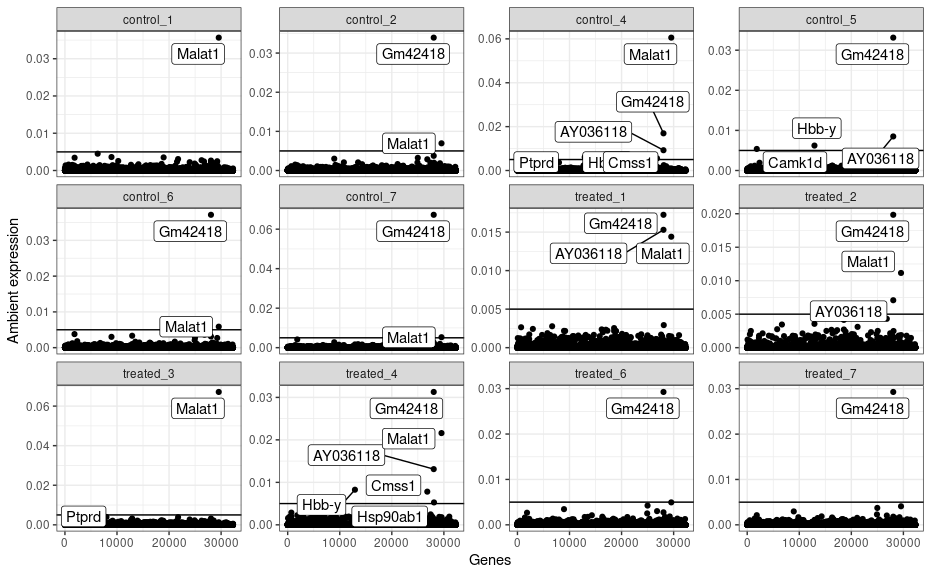

```r
crm$plotCbAmbExp(cutoff = 0.005)
```

## 9.5 Plot proportion of samples expressing ambient genes

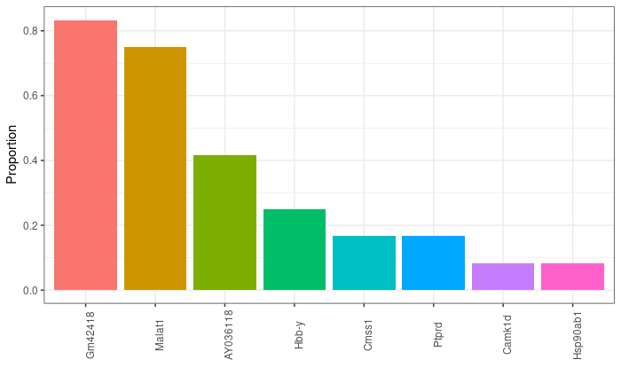

```r
crm$plotCbAmbGenes(cutoff = 0.005)
```

## 9.6 Add cellbender filtered cms

Then, we can add the cellbender filtered cms to our object. Additionally, it is recommended to generate new summary metrics from the adjusted cms which can then be plotted.

```r
crm$cms <- NULL
crm$addCms(cellbender = T)
crm$addSummaryFromCms()
crm$detailed.metrics <- NULL
crm$addDetailedMetrics()
qsave(crm, "crm_cellbender.qs", nthreads=10)
```